# Trabajo Grupal

Fabrizio Velasco

12/5/2022

# Introducción y objetivos:

El presente trabajo tiene como objetivo hacer un análisis exploratorio para comprobar o desmentir si los porcentajes que gasta cada gobierno en educación se ven influenciados por variables económicas, como son el porcentaje de crecimiento anual del PIB y porcentaje de gasto de consumo final del gobierno (como porcentaje del PIB). Cabe resaltar que la data utilizada en este trabajo fue extraída de la base de datos del Banco Mundial del año 2016 y tiene como unidad de análisis a los países.

Es por eso que en este trabajo se realizan pruebas estadísticas que buscan demuestrar si realmente hay relaciones de causalidad entre estas variables y el porcentaje de explicación que estas tendrían, para eso se realizará pruebas de regresión gaussiana y de regresión múltiple, además de otros diagnósticos de regresión, como son las pruebas de linealidad, homocedasticidad, normalidad de residuos, multicolinealidad y de valores influyentes. Asímismo, también se realiza análisis de conglomerados y análisis factorial, para luego, finalmente, terminar con las conclusiones

# Variables:

La variable dependiente elegida en esta ocasión es el Gasto Público en educación total (%PIB), y las independientes son el Crecimiento del PIB (%anual) y el Gasto en consumo final del gobierno en general (%PIB). Se seleccionó estas variables en términos del PIB para hacer un mejor análisis.

- Dependiente:
- GDE: Gasto público en educación total (%PIB)
- Independientes:
- GDP: Crecimiento del PIB (%anual)
- GFC: Gasto de consumo final del gobierno general (%PIB)

# PARTE 1:

# Regresión Lineal o Gaussiana:

Comenzaos este trabajo realizando dos regresiones lineales o gaussianas para comprobar si alguna de las variables independientes afectan a la dependiente

## Regresión 1:

Analizar si la variable independiente Crecimiento del PIB, afecta a la variable dependiente Gasto Público en educación (%PIB):

### Realizamos un gráfico de dispersión:

Este gráfico sirve para analizar de manera visual si podría haber correlación entre las dos variables; sin embargo, aún no indica si esta realmente existe.

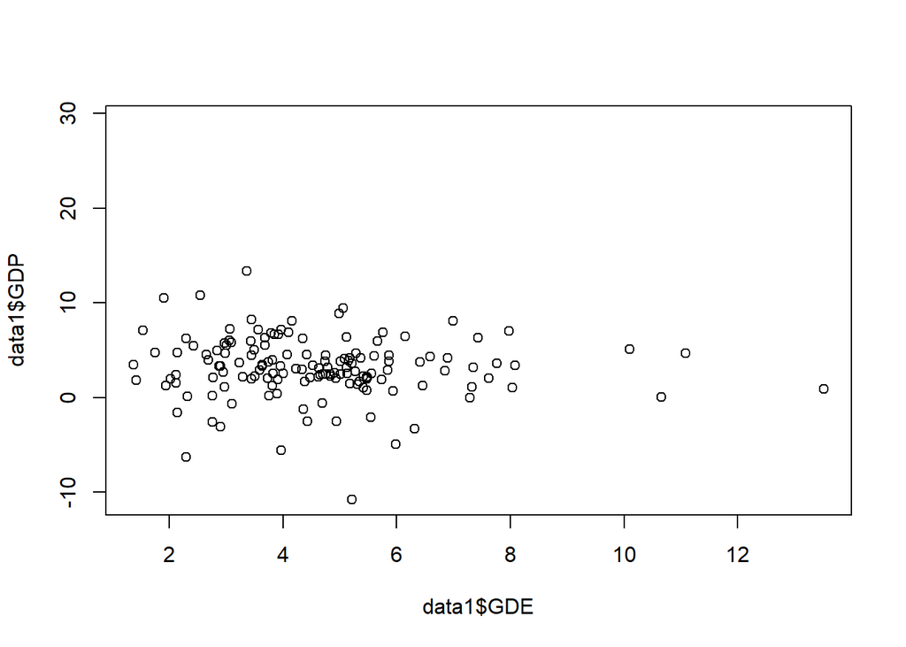

### Prueba de normalidad y correlación:

Después de ver el gráfico de dispersión continuamos con la prueba de correlación, para esto, primero se debe hallar la normalidad de las dos variables, esta prueba es importante pues con su resultados se determinará si la correlación se haya utilizando la prueba de Person o de Spearman. La normalidad se halla con la prueba lillie.test:

```r
library(nortest)
lillie.test(data1$GDE)
```

```
##
##  Lilliefors (Kolmogorov-Smirnov) normality test
##
## data:  data1$GDE
## D = 0.099382, p-value = 0.001244
```

```r
lillie.test(data1$GDP)
```

```
##
##  Lilliefors (Kolmogorov-Smirnov) normality test
##
## data:  data1$GDP
## D = 0.10826, p-value = 3.823e-06
```

Los resultados de la prueba indican que ambas variables tienen p-valores menores a 0.05 por lo que no presentan normalidad. Al saber que no presentan normalidad, toca hacer la prueba de correlación con el método de Spearman.

### Prueba de correlación 1:

Primero delimitamos cuáles serán las hipótesis para las pruebas de correlación:

- H0 = No existe correlación entre el Gasto público en educación total (%PIB) y Crecimiento anual del PIB
- H1 = Sí existe correlación entre el Gasto público en educación total (%PIB) y Crecimiento anual del PIB

```r
cor.test(data1$GDE, data1$GDP, method = c("spearman"))
```

```
##
##  Spearman's rank correlation rho
##
## data:  data1$GDE and data1$GDP
## S = 573024, p-value = 0.208
## alternative hypothesis: true rho is not equal to 0
## sample estimates:
##        rho
## -0.1048057
```

### Resultados:

En esta prueba, el p-valor sale mayor a 0.05 por lo que se acepta la Hipótesis nula y se demuestra que **no hay correlación** entre las dos variables y, en consecuencia, si se hace un modelo de regresión lineal, este indicaría que **no existe causalidad entre las variables** por lo que no es necesario crear el modelo de regresión lineal; sin embargo, este igual se va a realizar para demostrar que no existe tal relación.

### Modelo de regresión lineal:

Las hipótesis para la prueba F son las siguientes:

- H0: El modelo de regresión no es válido
- H1: El modelo de regresión es válido

```r
modelo1 <- lm(GDP~GDE, data=data)
anova(modelo1)
```

```
## Analysis of Variance Table
##
## Response: GDP
##            Df  Sum Sq Mean Sq F value Pr(>F)
## GDE         1   10.31  10.314  0.9901 0.3214
## Residuals 144 1499.96  10.416
```

```r
summary(modelo1)
```

```
##
## Call:
## lm(formula = GDP ~ GDE, data = data)
##
## Residuals:
##      Min       1Q   Median       3Q      Max
## -13.8480  -1.3181  -0.0354   1.5390  10.0714
##
## Coefficients:
##             Estimate Std. Error t value Pr(>|t|)
## (Intercept)   3.7994     0.7029   5.405 2.62e-07 ***
## GDE          -0.1410     0.1417  -0.995    0.321
## ---
## Signif. codes:  0 '***' 0.001 '**' 0.01 '*' 0.05 '.' 0.1 ' ' 1
##
## Residual standard error: 3.227 on 144 degrees of freedom
##   (71 observations deleted due to missingness)
## Multiple R-squared:  0.006829,   Adjusted R-squared:  -6.8e-05
## F-statistic: 0.9901 on 1 and 144 DF,  p-value: 0.3214
```

### Resultados:

En esta regresión, el p-valor sigue siendo mayor a 0.05 por lo que nuevamente se acepta la hipótesis nula y se demuestra que no hay relación de causalidad entre las variables, es decir que el crecimiento anual del PIB no explica el gasto público en educación total (%PIB)

## Regresión 2:

Analizar si la variable independiente, Gasto de consumo final del gobierno (%PIB), afecta a la variable dependiente Gasto Público en educación:

### Creamos un gráfico de dispersión:

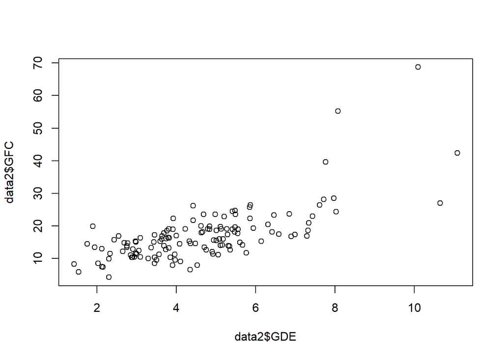

### Prueba de normalidad y correlación:

```r
library(nortest)
lillie.test(data2$GDE)
```

```
##
##  Lilliefors (Kolmogorov-Smirnov) normality test
##
## data:  data2$GDE
## D = 0.084805, p-value = 0.02104
```

```r
lillie.test(data2$GFC)
```

```
##
##  Lilliefors (Kolmogorov-Smirnov) normality test
##
## data:  data2$GFC
## D = 0.14862, p-value = 2.699e-10
```

Ambos p-valores son menores a 0.05 por lo que no presentan normailidad y podemos continuar haciendo la prueba de correlación siguiendo el método de Spearman

### Prueba de correlación 2:

Delimitamos cuáles serán las hipótesis para las pruebas de correlación:

- H0 = No existe correlación entre el Gasto público en educación total (%PIB) y el Gasto de consumo final del gobierno (%PIB)
- H1 = Sí existe correlación entre el Gasto público en educación total (%PIB) y el Gasto de consumo final del gobierno (%PIB)

```r
cor.test(data2$GDE, data2$GFC, method = c("spearman"))
```

```
##
##  Spearman's rank correlation rho
##
## data:  data2$GDE and data2$GFC
## S = 130127, p-value < 2.2e-16
## alternative hypothesis: true rho is not equal to 0
## sample estimates:
##       rho
## 0.6605149
```

En este caso, el p-valor es menor a 0.05 por lo que se rechaza la hipótesis nula y se asume que sí hay relación entre las dos variables, ahora procedeos a hacer el modelo de regresión lineal para hallar la causalidad.

## Modelo de regresión lineal:

Las hipótesis para la prueba F son las siguientes:

- H0: El modelo de regresión no es válido
- H1: El modelo de regresión es válido

```r
modelo2 <- lm(GFC~GDE, data=data2)
anova(modelo2)
```

```
## Analysis of Variance Table
##
## Response: GFC
##            Df Sum Sq Mean Sq F value    Pr(>F)
## GDE         1 4378.0    4378  128.76 < 2.2e-16 ***
## Residuals 130 4420.3      34
## ---
## Signif. codes:  0 '***' 0.001 '**' 0.01 '*' 0.05 '.' 0.1 ' ' 1
```

```r
summary(modelo2)
```

```
##
## Call:
## lm(formula = GFC ~ GDE, data = data2)
##
## Residuals:
##    Min     1Q Median     3Q    Max
## -9.708 -3.288 -0.288  2.870 34.019
##
## Coefficients:
##             Estimate Std. Error t value Pr(>|t|)
## (Intercept)   2.2329     1.3990   1.596    0.113
## GDE           3.2187     0.2837  11.347   <2e-16 ***
## ---
## Signif. codes:  0 '***' 0.001 '**' 0.01 '*' 0.05 '.' 0.1 ' ' 1
##
## Residual standard error: 5.831 on 130 degrees of freedom
##   (46 observations deleted due to missingness)
## Multiple R-squared:  0.4976, Adjusted R-squared:  0.4937
## F-statistic: 128.8 on 1 and 130 DF,  p-value: < 2.2e-16
```

### Resultados:

Como el p-valor es menor a 0.05 entonces rechazamos la H0, por lo que concluimos que el modelo sí es válido como modelo de predición, es decir, existe una relación lineal entre el Gasto público en educación total (%PIB) y el Gasto de consumo final del gobierno (%PIB)

Como el coeficiente R-cuadrado ajustado es 0.4937, significa que este modelo de regresión explica en un 49.37%

### Gráfico de la ecuación:

Realizamos un gráfico de la ecuación del modelo de regresión lineal:

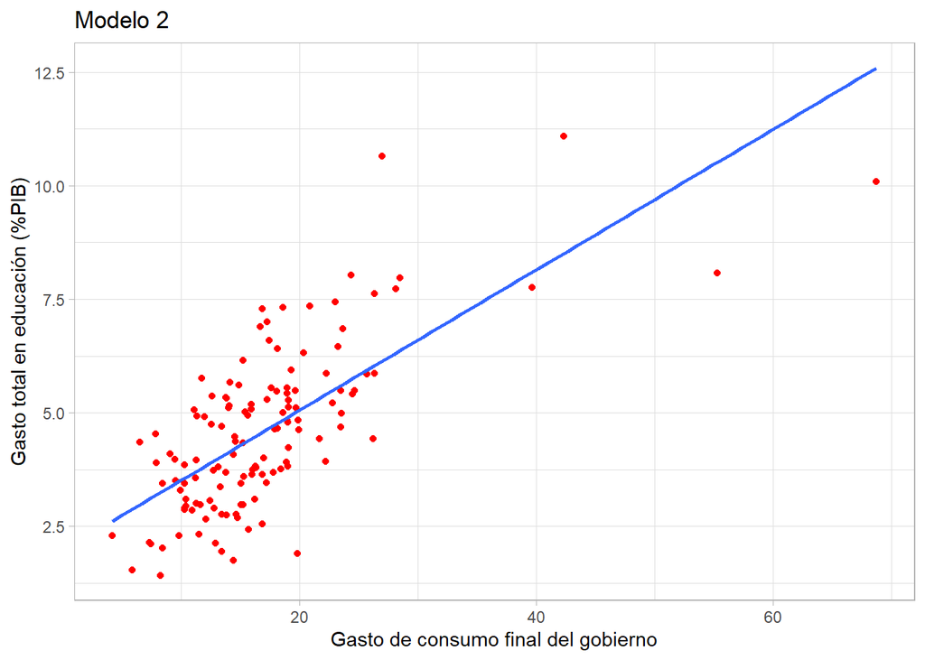

# Regresión lineal multivariada:

Ahora vamos a hacer una regresión lineal multivariada con las mismas variables, manteniendo El Gasto Público en educación total (GDE) como variable dependiente y Crecimiento del PIB (GDP) y Gasto en consumo final del gobierno general (GFC) como variables independientes:

```r
library(stargazer)
modelo3=formula(data$GDE~data$GDP+data$GFC)
regresión1=lm(modelo3,data=data)
stargazer(regresión1,type = "text")
```

```
##
## ===============================================
##                         Dependent variable:
##                     ---------------------------
##                                 GDE
## -----------------------------------------------
## GDP                           -0.021
##                               (0.036)
##
## GFC                          0.152***
##                               (0.014)
##
## Constant                     2.058***
##                               (0.288)
##
## -----------------------------------------------
## Observations                    131
## R2                             0.492
## Adjusted R2                    0.484
## Residual Std. Error      1.280 (df = 128)
## F Statistic           61.947*** (df = 2; 128)
## ===============================================
## Note:               *p<0.1; **p<0.05; ***p<0.01
```

Este modelo si aporta pues su p-valor es menor a 0.05, explica un 48.4% Sin embargo, la única variable que explica es el consumo final del gobierno general (GFC), pues su p-valor es menor a 0.05.

### Ecuación de la regresión:

Para hacer la ecuación se necesita ver de forma más precisa los coeficientes de los interceptos, eso se realiza con summary:

```r
summary(regresión1)
```

```
##
## Call:
## lm(formula = modelo3, data = data)
##
## Residuals:
##     Min      1Q  Median      3Q     Max
## -2.9612 -0.8842 -0.1030  0.7791  4.4814
##
## Coefficients:
##             Estimate Std. Error t value Pr(>|t|)
## (Intercept)  2.05755    0.28784   7.148 5.97e-11 ***
## data$GDP    -0.02070    0.03566  -0.580    0.563
## data$GFC     0.15243    0.01376  11.080  < 2e-16 ***
## ---
## Signif. codes:  0 '***' 0.001 '**' 0.01 '*' 0.05 '.' 0.1 ' ' 1
##
## Residual standard error: 1.28 on 128 degrees of freedom
##   (86 observations deleted due to missingness)
## Multiple R-squared:  0.4919, Adjusted R-squared:  0.4839
## F-statistic: 61.95 on 2 and 128 DF,  p-value: < 2.2e-16
```

GDE = 2.05755 -0.02070 GDP + 0.15243 GFC

# Diagnósticos de regresión:

Se realiza los diagnósticos de regresión con el modelo de regresión múltiple.

### Linealidad:

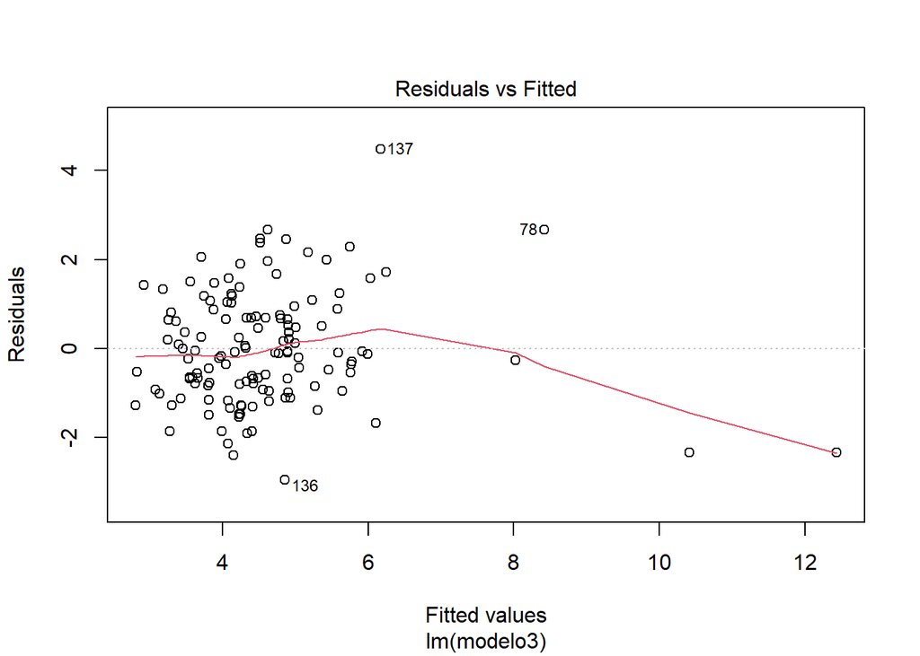

```r
plot(regresión1, 1)
```

El análisis de linealidad no sale muy bien pues la linea roja no está cerca de la linea horizontal

### Homocedasticidad:

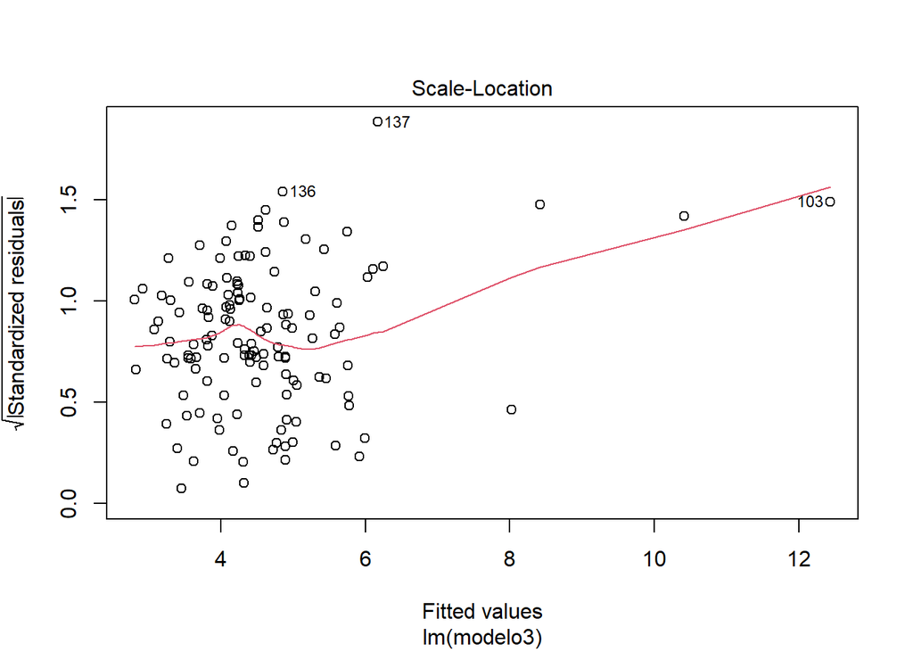

```r
plot(regresión1, 3)
```

```r
library(lmtest)
bptest(regresión1)
```

```
##
##  studentized Breusch-Pagan test
##
## data:  regresión1
## BP = 12.47, df = 2, p-value = 0.001959
```

La probabilidad de homocedasticidad es muy baja pues tiene un p-valor menor a 0.05, por lo que se rechaza que este modelo tenga homocedasticidad

### Normalidad de residuos:

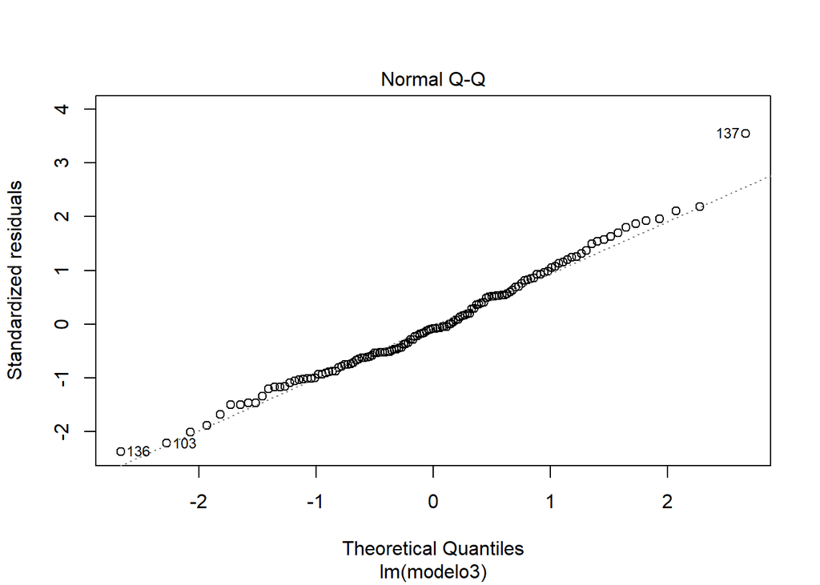

```r
plot(regresión1, 2)
```

```r
shapiro.test(regresión1$residuals)
```

```
##
##  Shapiro-Wilk normality test
##
## data:  regresión1$residuals
## W = 0.98481, p-value = 0.1533
```

En este caso, la prueba de normalidad de residuos muestra un p-valor mayor a 0.05, lo cual está bien porque muestra que los residuos se distribuyen de manera normal , esto se ve expresado en el gráfico porque los valores están bien cerca de la línea diagonal

### No multicolinealidad:

```r
library(DescTools)
VIF(regresión1)
```

```
## data$GDP data$GFC
## 1.001925 1.001925
```

Como ninguna variable sale mayor a 5, ninguna es candidata a ser retirada y muestra que estas no están muy correlacionadas entre sí, es decir, muestra que estas no buscan explicar el mismo fenómeno

### Valores influyentes:

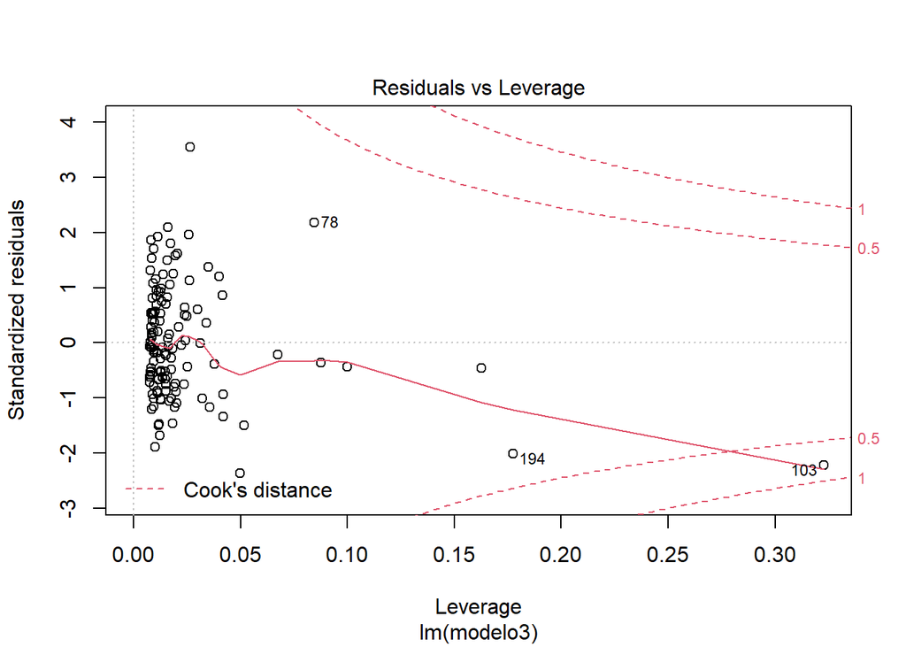

```r
plot(regresión1, 5)
```

El gráfico muestra que efectivamente hay valores atípicos que influyen negativamente en la regresión, los cuales podrían ser retirados para obtener mejores resultados.

# PARTE 2:

# Análisis de conglomerados:

Empezamos viendo las variables que están en la data:

```r
list(names(data))
```

```
## [[1]]
##  [1] "Country Name" "Country Code" "FLF"          "WSC"          "ARF"
##  [6] "GDE"          "BSS"          "UET"          "GEE"          "GDP"
## [11] "GFC"          "IVA"          "GEI"          "CDA"
```

Nos quedamos solo con los datos que necesitamos, en este caso añadiremos 3 variables más, que son las siguientes:

- GEE = Gasto total del gobierno en educación (% del gasto de gobierno) –> se diferencia de la variable GDE en que esta es como porcentaje del PIB
- BSS = Personas que usan al menos servicios sanitarios básicos (% de población rural)
- UET = Desempleo total (% del total de la fuerza laboral)

```r
data3 = data[,c(1,6:11)]
```

### Verificando las distribuciones:

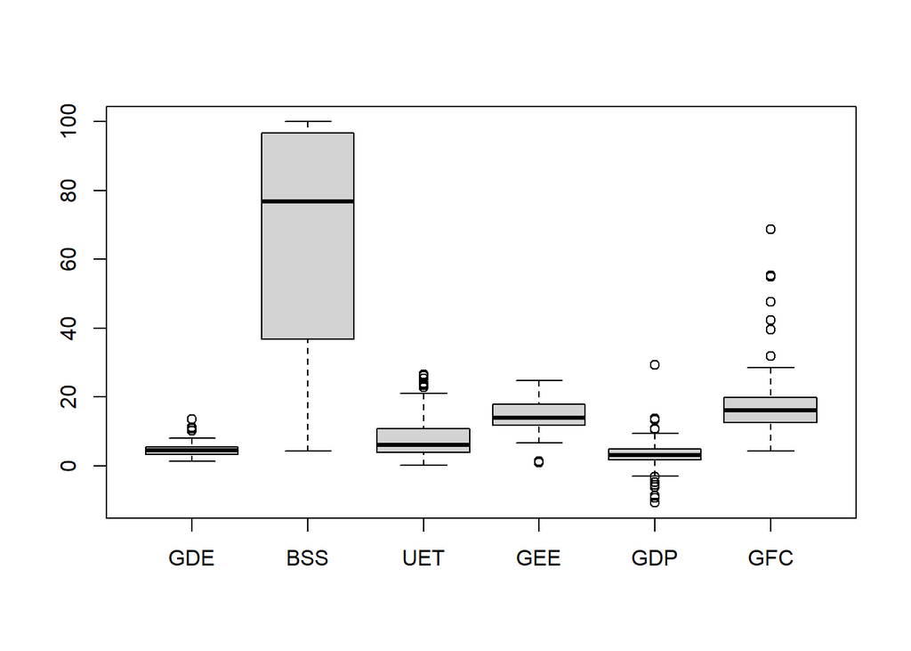

```r
boxplot(data3[,-1])
```

```r
library(BBmisc)
```

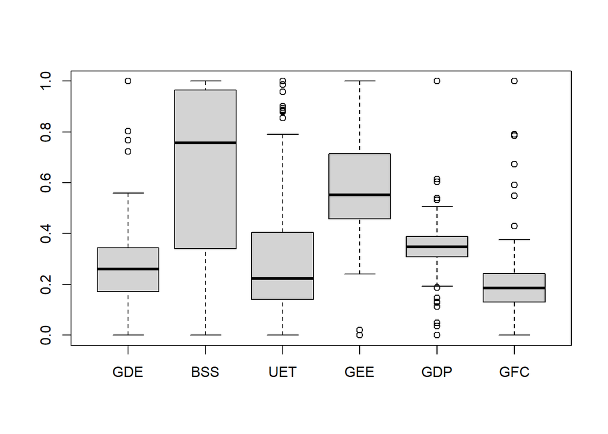

```r
boxplot(normalize(data3[,-1],method='range',range=c(0,1)))
```

```r
data3[,-1]=normalize(data3[,-1],method='standardize')
data3=data3[complete.cases(data3),]

summary(data3)
```

```
##  Country Name            GDE                BSS                UET
##  Length:110         Min.   :-1.63367   Min.   :-1.89686   Min.   :-1.24612
##  Class :character   1st Qu.:-0.58361   1st Qu.:-0.80086   1st Qu.:-0.67254
##  Mode  :character   Median :-0.07805   Median : 0.26931   Median :-0.39882
##                     Mean   :-0.02703   Mean   :-0.01699   Mean   :-0.07105
##                     3rd Qu.: 0.46762   3rd Qu.: 0.93833   3rd Qu.: 0.20449
##                     Max.   : 3.17090   Max.   : 1.03781   Max.   : 3.09826
##       GEE                GDP                GFC
##  Min.   :-1.72565   Min.   :-3.56286   Min.   :-1.5633
##  1st Qu.:-0.52861   1st Qu.:-0.28914   1st Qu.:-0.5895
##  Median : 0.03322   Median : 0.05652   Median :-0.2264
##  Mean   : 0.09470   Mean   : 0.07760   Mean   :-0.1436
##  3rd Qu.: 0.70440   3rd Qu.: 0.58043   3rd Qu.: 0.1755
##  Max.   : 2.14076   Max.   : 2.62639   Max.   : 4.4574
```

### Correlaciones:

```r
cor(data3[,-1])
```

```
##            GDE         BSS         UET         GEE         GDP         GFC
## GDE  1.0000000  0.35092976  0.22938531  0.37162742 -0.11869943  0.65051026
## BSS  0.3509298  1.00000000  0.04521728 -0.06563114 -0.03204978  0.17026388
## UET  0.2293853  0.04521728  1.00000000 -0.14661914 -0.16127639  0.31978298
## GEE  0.3716274 -0.06563114 -0.14661914  1.00000000  0.22048585 -0.14654025
## GDP -0.1186994 -0.03204978 -0.16127639  0.22048585  1.00000000 -0.09597343
## GFC  0.6505103  0.17026388  0.31978298 -0.14654025 -0.09597343  1.00000000
```

### Cambio de monotonía:

```r
data3$GDP=-1*data3$GDP

cor(data3[,-1])
```

```
##           GDE         BSS         UET         GEE         GDP         GFC
## GDE 1.0000000  0.35092976  0.22938531  0.37162742  0.11869943  0.65051026
## BSS 0.3509298  1.00000000  0.04521728 -0.06563114  0.03204978  0.17026388
## UET 0.2293853  0.04521728  1.00000000 -0.14661914  0.16127639  0.31978298
## GEE 0.3716274 -0.06563114 -0.14661914  1.00000000 -0.22048585 -0.14654025
## GDP 0.1186994  0.03204978  0.16127639 -0.22048585  1.00000000  0.09597343
## GFC 0.6505103  0.17026388  0.31978298 -0.14654025  0.09597343  1.00000000
```

### Preparamos la data para la clusterización:

```r
dataClus=data3[,-1]
row.names(dataClus)=data3$`Country Name`
```